# Documento de Análisis Descriptivo y Exploratorio (EDA)

Etapa 3 — Entregable ejecutivo consolidado

Edwin Silva Salas & Edwin Henao Ochoa

03 de agosto de 2026

[figure not shown]

[figure not shown]

Pontificia Universidad Javeriana Cali  
Facultad de Ingeniería y Ciencias.  
MAESTRÍA EN CIENCIA DE DATOS

# Documento de Análisis Descriptivo y Exploratorio (EDA)

Etapa 3 — Entregable ejecutivo consolidado

**Edwin Silva Salas**  
**Edwin Henao Ochoa**

[output not shown]

# Resumen ejecutivo

Este documento consolida los hallazgos de la **Etapa 3 — Análisis descriptivo y exploratorio de datos (EDA)** del proyecto de pronóstico de la **frecuencia y la duración** de interrupciones eléctricas (variables proxy asociadas a *SAIFI* / *SAIDI*, sin estimar los indicadores regulatorios en sentido estricto) en la red de distribución. El objetivo fue caracterizar la calidad del panel, diagnosticar distribuciones y extremos, identificar patrones temporales y espaciales, y evaluar asociaciones entre clima y operación para orientar la **Etapa 4 (modelado)**.

# 1. Objetivo, alcance y fuentes de datos

## 1.1 Objetivo (OE2)

Comprender el comportamiento de los datos e identificar patrones, relaciones y comportamientos relevantes que orienten a la toma de decisiones tanto para la empresa como para el modelado predictivo de continuidad del servicio.

## 1.2 Universo analítico

Resumen operativo del dataset de modelado (data_agrupada_mod.csv)

| Conjunto | Archivo | Horizonte | Grano | Uso en EDA |
| --- | --- | --- | --- | --- |
| Panel consolidado | `data consolidada.csv` | 2021–2025 | Activo × día | Calidad (faltantes, extremos) |
| Tabla agrupada $D_{\mathrm{EDA}}$ | `data agrupada.csv` | 2021–2025 | Cuadrante × semana | §5.3.1–5.3.5 (90 128 filas) |
| Tabla de modelado $D_{\mathrm{mod}}$ | `data agrupada mod.csv` | 2024–2025 | Cuadrante × semana | §5.3.6–5.3.9 y Etapa 4 (36 120 filas) |

| Metrica | Valor |
| --- | --- |
| Filas (D_mod) | 36120.0 |
| Cuadrantes | 344.0 |
| Semanas | 105.0 |
| Total eventos | 33410.0 |
| Eventos 2024 | 15211.0 |
| Eventos 2025 | 18199.0 |
| Media eventos/semana | 318.2 |

# 2. Calidad de datos (§5.3.1–5.3.2)

## 2.1 Datos faltantes

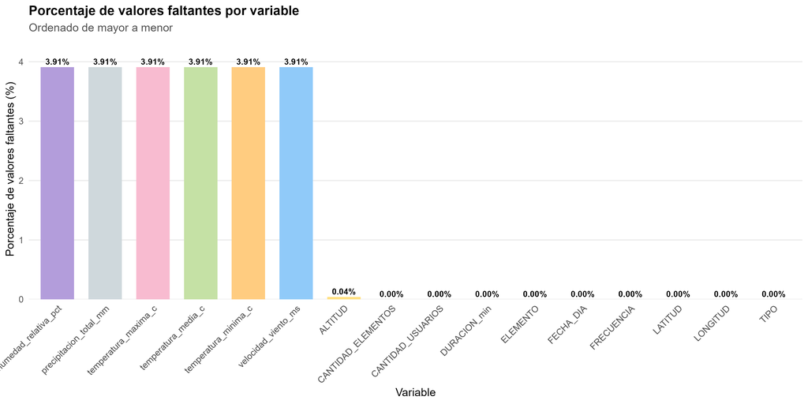

Porcentaje de NA por variable en el panel consolidado (§5.3.1).

Cada barra representa una variable de la base de datos, y su longitud indica qué porcentaje de registros llega vacío (sin dato). En términos simples, es una “radiografía de la calidad de la información” con la que trabaja la empresa.

La gran mayoría de la información está completa: el **96 %** de los registros no tiene huecos. Los vacíos se concentran casi exclusivamente en las variables de **clima** (3,91 %), que provienen de una fuente externa (satélite NASA POWER), no de los sistemas internos. Las variables críticas del negocio —las que describen las interrupciones del servicio— **no presentan vacíos**.

Confirma que los sistemas operativos (OMS, GIS) están registrando de forma confiable los eventos de interrupción; el riesgo de calidad de datos no está en la operación, sino en un insumo externo y secundario. Esto da **confianza para construir modelos predictivos** sin necesidad de costosos procesos de limpieza o de descartar grandes volúmenes de información. El hallazgo no evidente es que la calidad del dato **no es un obstáculo** para avanzar al modelado.

## 2.2 Valores extremos

Un **valor extremo** (o atípico) es una observación numérica que se aparta de la mayoría del conjunto según una regla estadística. **No implica automáticamente un error**: puede reflejar un evento operativo o climático real (p. ej. una semana de lluvia intensa o una interrupción de gran magnitud), o bien una inconsistencia de registro que debe validarse con el área de operación.

### Cómo se identificaron

Sobre `data_agrupada.csv` ($N_{\mathrm{agr}} = 90\,128$; cuadrante × semana) y, de forma complementaria, sobre el panel consolidado diario, se aplicaron **tres reglas univariadas** por variable:

| Regla | Criterio | Interpretación |
| --- | --- | --- |
| **Tukey (IQR 1,5)** | Fuera de $[Q_1 - 1{,}5\,\mathrm{IQR},\; Q_3 + 1{,}5\,\mathrm{IQR}]$ | Atípico moderado (criterio clásico de diagrama de caja) |
| **Tukey ampliado (IQR 3,0)** | Fuera de $[Q_1 - 3\,\mathrm{IQR},\; Q_3 + 3\,\mathrm{IQR}]$ | Atípico severo |
| **Percentiles P1–P99** | Por debajo del percentil 1 o por encima del percentil 99 | Cola inferior o superior del 1 % de la distribución |

En variables con **exceso de ceros** (semanas sin interrupción), $Q_1 = Q_3 = 0$ y la regla de Tukey sobre el total marca cualquier semana con evento como extrema; por ello el análisis operativo relevante se realiza sobre el subconjunto **semanas con evento** (`valor > 0`).

### Qué se encontró

**Bloque climático semanal**

- Temperaturas, humedad y viento: extremos **escasos** bajo Tukey (0 %–0,03 %); distribuciones casi simétricas.
- `precip_total_semana`: **excepción** por acumulado semanal asimétrico a la derecha — Tukey 1,5 marca el **6,21 %** de las semanas y el 3,0 el **1,79 %**; percentiles P1–P99 solo el **0,99 %**. Corresponde a **semanas de lluvia intensa plausibles** (máximo 198,1 mm), no a errores de medición.

**Bloque operativo (semanas con evento)**

- Mediana de `usuarios_afectados`: 52 usuarios; **máximo: 69 928**.
- Mediana de `duracion_total`: 19,7 h; **máximo: 2 227 h** (~93 días acumulados en una semana), valor que **sugiere revisar** trazabilidad del registro.
- Tukey marca entre **11,6 % y 15,2 %** de las semanas con evento como extremas — proporción **esperable** en colas pesadas, no necesariamente errores.

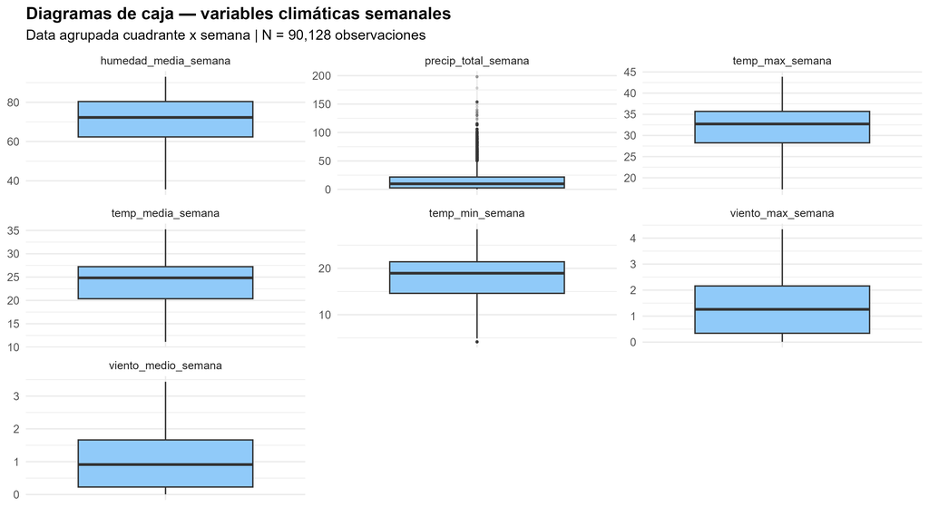

Diagramas de caja de variables climaticas semanales en la tabla agrupada (Seccion 5.3.2).

Cada “caja” resume cómo se comporta una variable climática: la caja contiene la mitad central de los valores habituales, y los puntos que quedan por fuera son los **casos fuera de lo normal**. Es la forma visual de detectar qué tan dispersos o atípicos son los datos.

Temperatura, humedad y viento se comportan de forma **estable y predecible** (cajas compactas, pocos puntos fuera). La **precipitación** es la excepción: tiene una cola de valores altos, que corresponden a **semanas de lluvia intensa reales** (hasta 198 mm acumulados), no a errores.

El gráfico delimita qué es un valor climático inusual y qué no, insumo directo para las reglas de tratamiento de la Etapa 4. El hallazgo no evidente es que ninguna variable climática presenta valores imposibles: la calidad del bloque meteorológico es alta y no requiere depuración.

### Qué hacer en un caso real cuando un valor sale de lo normal

En operación y en el paso a modelado, se recomienda **no eliminar automáticamente** los extremos detectados en el EDA. El procedimiento sugerido es:

1. **Clasificar el origen**
   - *Plausible operativo/climático*: precipitación alta en temporada de lluvias; pico de usuarios afectados en evento mayor; múltiples eventos en la misma semana-cuadrante.
   - *Sospechoso de registro*: duraciones físicamente inverosímiles (p. ej. semanas con continuidad acumulada equivalente a meses), conteos negativos o saltos sin evento asociado en OMS.
2. **Validar con fuente y negocio**
   - Contrastar con OMS, SCADA o GIS el identificador de evento, fechas y magnitud.
   - Consultar al área de continuidad si el valor corresponde a un incidente conocido o a una regla de cálculo (p. ej. suma de duraciones de eventos solapados).
3. **Decidir tratamiento (Etapa 4)**
   - **Mantener** si el extremo es real y representa el fenómeno a predecir.
   - **Winsorizar o transformar** (`log(1+x)`) si la cola distorsiona el modelo pero el dato es válido.
   - **Corregir o excluir puntualmente** solo tras validación documentada (error confirmado de registro).
   - **No aplicar** la regla de Tukey sobre el panel completo en variables cero-infladas; usar subconjunto con evento o modelos aptos para ceros (Poisson, ZIP, etc.).

En esta **Etapa 3** no se excluyeron ni transformaron observaciones: el objetivo fue **diagnosticar y documentar** para fundamentar las decisiones de la Etapa 4.

**Implicación Etapa 4:** definir reglas de winsorización, transformaciones o exclusión puntual solo para extremos validados; priorizar modelos que toleren colas pesadas y exceso de ceros en el bloque operativo.

# 3. Caracterización univariada (§5.3.3–5.3.4)

## 3.1 Estadísticos descriptivos

Sobre `data_agrupada.csv` ($N_{\mathrm{agr}} = 90\,128$):

**Clima semanal:** distribuciones casi simétricas (CV 0,16–0,81), excepto `precip_total_semana` (mediana 9,8 mm; media 16,0 mm; CV = 1,17; asimetría 1,98; máximo 198,1 mm).

**Operativo:** mediana 0 en las cuatro métricas; **74,9 %** de semanas-cuadrante sin eventos. Con evento: `usuarios_afectados` hasta 69 928; `n_eventos` hasta 58 por semana-cuadrante.

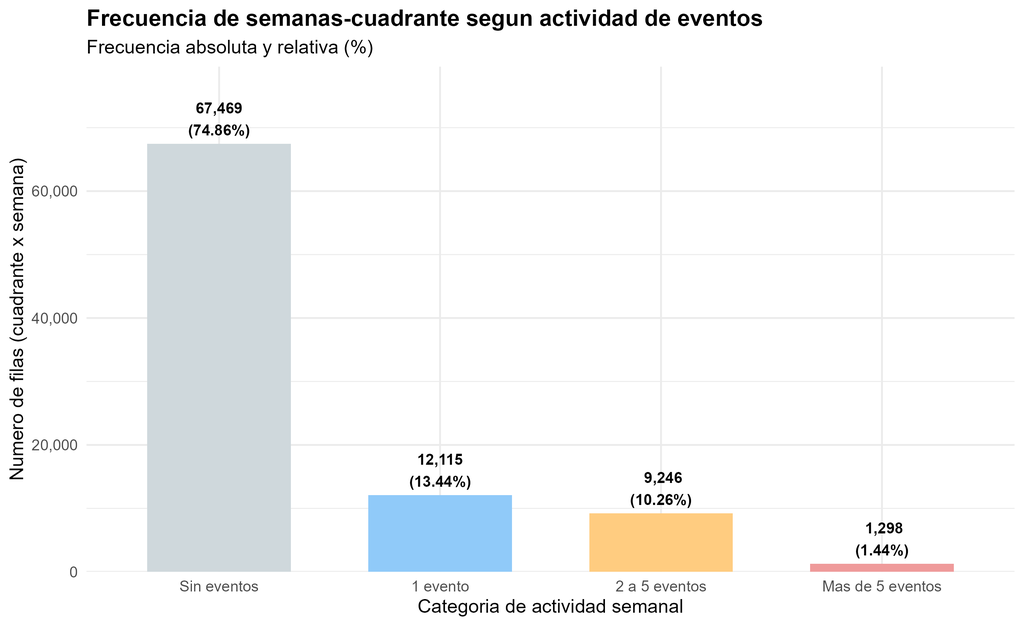

Distribución de actividad semanal por cuadrante (§5.3.3).

Compara cuántas combinaciones de zona-semana tienen interrupciones frente a cuántas no tienen ninguna. Responde a la pregunta: ¿con qué frecuencia ocurren realmente las fallas en el territorio?

En cerca del **75 %** de las semanas-zona **no ocurre ninguna interrupción**. Las fallas no están repartidas de manera uniforme: se concentran en pocas zonas y pocas semanas. Cuando ocurren, su magnitud varía enormemente (desde unos pocos usuarios afectados hasta casi 70 000).

Muestra que la afectación del servicio es un fenómeno **concentrado, no generalizado**. El hallazgo no evidente es que **dirigir recursos a todo el territorio por igual es ineficiente**: la mayor parte del esfuerzo de prevención debería enfocarse en el pequeño grupo de zonas y temporadas donde realmente se concentran los eventos.

## 3.2 Análisis de distribución

Dos regímenes claros:

1. **Bloque climático estable**, con precipitación como excepción asimétrica (9,1 % de semanas con 0 mm).
2. **Bloque operativo cero-inflado** (72,5–74,9 % ceros) con curtosis elevada en semanas con evento.

La transformación `log(1 + precip)` aproxima la precipitación a simetría; las variables operativas requieren modelos aptos para exceso de ceros (Poisson, ZIP, etc.).

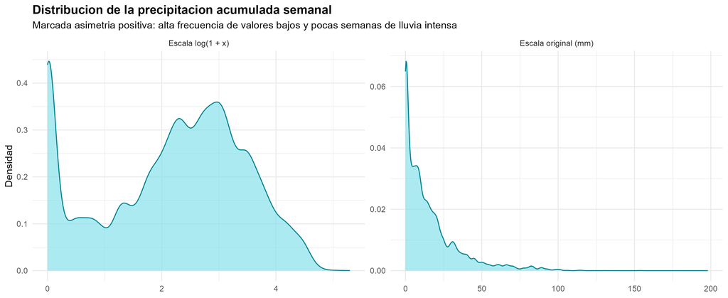

Precipitación semanal: escala original vs log(1+x) (§5.3.4).

La lluvia tiene un patrón **desbalanceado**: muchas semanas con precipitación baja o nula (9,1 % con 0 mm) y unas pocas con acumulados altos.

Confirma que la variable requiere transformación antes de entrar a un modelo lineal. El hallazgo no evidente es que la escala logarítmica desplazada la vuelve casi simétrica, de modo que el desbalance no es un obstáculo técnico para el modelado.

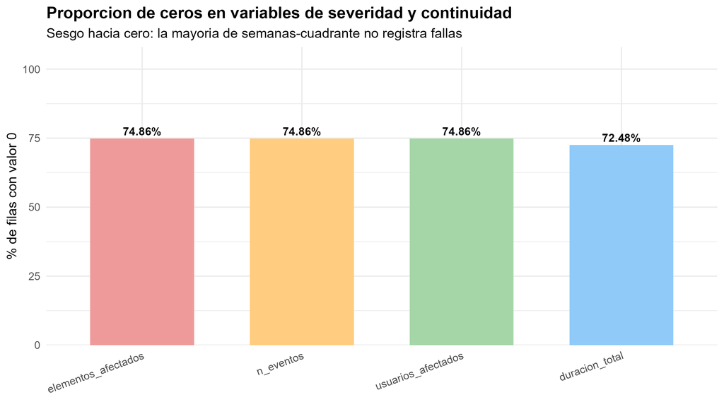

Proporción de ceros en variables operativas (§5.3.4).

Qué proporción de los registros operativos vale cero (sin interrupción) en cada variable del negocio.

Entre el **72 % y el 75 %** de los registros son ceros: la operación “normal” es que no haya fallas. Las interrupciones son eventos relativamente escasos pero de alto impacto cuando ocurren.

Refuerza que la continuidad del servicio es, en general, buena, y que el reto está en **predecir los eventos poco frecuentes pero costosos**. El hallazgo no evidente es que cualquier herramienta de predicción debe diseñarse específicamente para detectar esos casos raros, no para describir el promedio.

# 4. Dinámica temporal y dataset de modelado (§5.3.5)

## 4.1 Serie territorial 2021–2025

- **262 semanas**; mediana 124,5 eventos/semana (media 188,5).
- Régimen bajo 2021–2023; incremento marcado desde 2024 (15 211 eventos) y 2025 (18 199).
- **Estacionalidad:** mayor actividad en meses de lluvias.
- **ACF:** rezago 1 = 0,92; componente anual (rezago 52 ≈ 0,43).

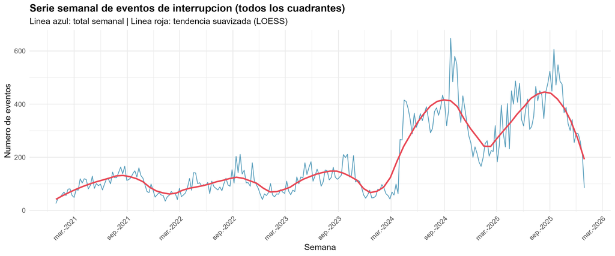

Serie semanal de eventos con tendencia LOESS, 2021–2025 (§5.3.5).

La evolución semana a semana del número de interrupciones entre 2021 y 2025, con una línea de tendencia que suaviza los altibajos.

Se observa un **incremento marcado a partir de 2024**, además de subidas y bajadas que se repiten cada año (estacionalidad ligada a las temporadas de lluvia). Importante: parte de ese “salto” no significa que el servicio haya empeorado, sino que **a partir de 2024 se registran mucho mejor los eventos** (ver gráfico de cobertura más adelante).

Permite distinguir entre un **deterioro real** y una **mejora en la captura del dato**. El hallazgo no evidente es que las comparaciones históricas de indicadores (SAIDI/SAIFI) antes y después de 2024 pueden ser engañosas si no se considera este cambio de registro, lo que tiene impacto directo en reportes regulatorios y metas internas.

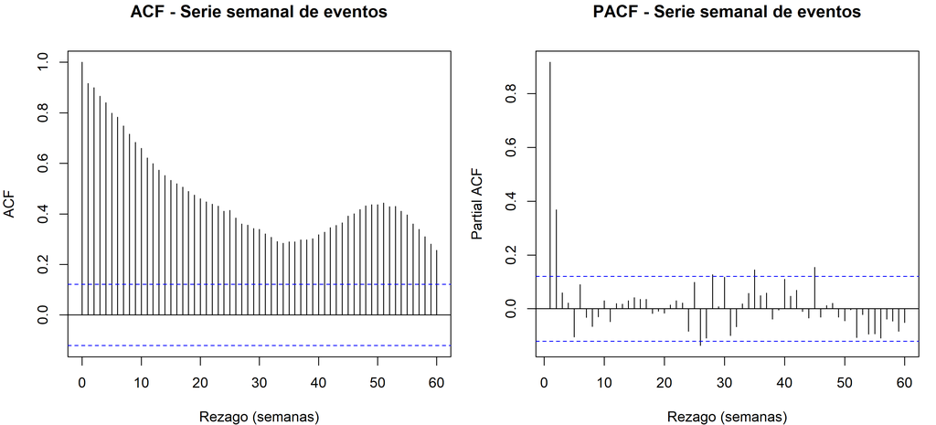

ACF/PACF de la serie semanal territorial (§5.3.5).

Mide qué tanto se “parece” una semana a las semanas anteriores; es decir, si lo que pasó recientemente ayuda a anticipar lo que viene.

Existe una **fuerte memoria** en los datos: una semana con muchas fallas tiende a estar seguida por otra con comportamiento similar (correlación de 0,92 con la semana previa), y aparece también un patrón que se repite cada año.

Confirma que el comportamiento de las fallas **es predecible** a partir de la historia reciente y del calendario. El hallazgo no evidente es que la empresa tiene una base sólida para **planear con anticipación** cuadrillas, materiales y mantenimiento, porque el futuro cercano se parece al pasado inmediato.

## 4.2 Delimitación de $D_{\mathrm{mod}}$

[output not shown]

**$D_{\mathrm{mod}}$:** 2024–2025 → 36 120 filas, 344 cuadrantes, 105 semanas, 33 410 eventos. Partición natural: entrenamiento 2024 / prueba 2025.

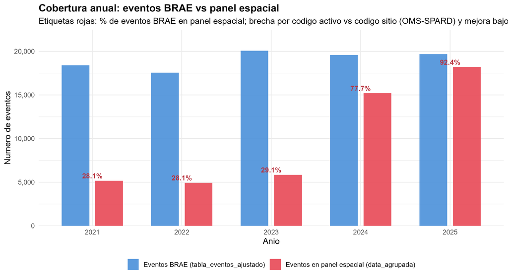

Cobertura anual emparejamiento evento–elemento vs panel espacial (§5.3.5).

Qué porcentaje de las fallas registradas se logró ubicar correctamente en el mapa (asociar a un activo y a una zona) en cada año.

Este es uno de los hallazgos **más relevantes y menos visibles**: explica por qué los datos previos a 2024 no son comparables con los actuales. Por eso el análisis y el modelo se construyen sobre **2024–2025**, donde la información es confiable. La lección de negocio es clara: **la trazabilidad geográfica de las fallas mejoró drásticamente**, y mantener esa calidad de registro es clave para cualquier analítica futura.

# 5. Patrones y visualización sobre $D_{\mathrm{mod}}$ (§5.3.6)

Análisis restringido a 2024–2025 con cobertura homogénea.

**Temporal:** media ≈ 318 eventos/semana; 287 (2024) → 350 (2025); ACF rezago 1 = 0,80; estacionalidad marcada entre meses.

**Espacial:** top 10 cuadrantes concentran 20,5 % de eventos; 49 cuadrantes (14,2 %) en nivel *Alta*.

**Clima–evento:** asociaciones positivas pero **débiles**; el viento encabeza ($\rho \approx 0{,}14$) y la precipitación le sigue ($\rho \approx 0{,}07$).

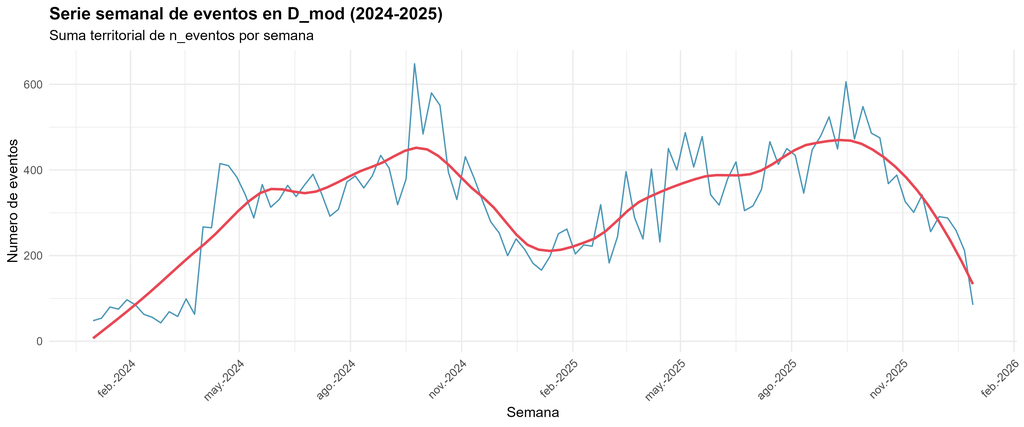

Serie semanal de eventos en el dataset de modelado (Seccion 5.3.6).

La evolución semanal de las interrupciones ya en el periodo confiable (2024–2025).

Aun con datos limpios y comparables, **la carga de eventos crece**. El hallazgo no evidente es que la presión sobre la operación va en aumento, lo que justifica invertir en capacidad predictiva y preventiva antes de que el crecimiento impacte los indicadores regulatorios.

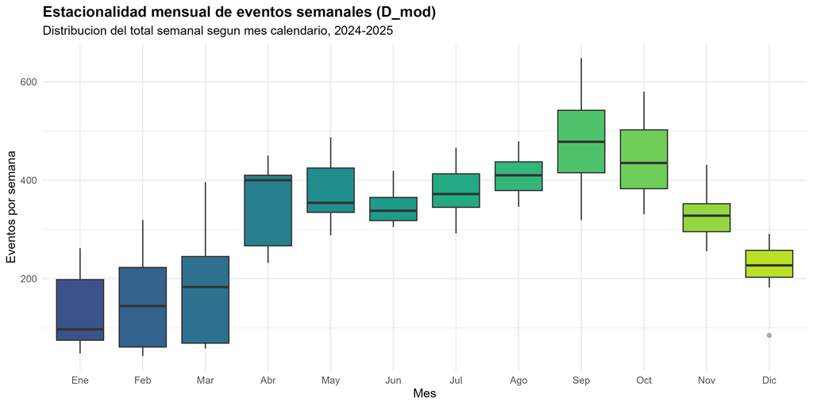

Estacionalidad mensual en el dataset de modelado (Seccion 5.3.6).

Cómo se distribuyen las fallas a lo largo de los meses del año.

Hay meses claramente más críticos que otros. La diferencia entre meses tranquilos y meses pico es sustancial, aunque —como se ve más adelante— el acumulado semanal de lluvia **no** explica ese patrón.

Permite **planificar el año por temporadas**: reforzar cuadrillas, inventarios y disponibilidad en los meses de mayor riesgo, y optimizar costos en los meses tranquilos. El hallazgo no evidente es que la estacionalidad es lo bastante marcada como para construir un **calendario operativo basado en datos**, incluso sin un predictor climático fuerte.

[figure not shown]

Dispersion precipitacion semanal vs frecuencia de eventos (Seccion 5.3.6).

Cada punto es una semana-zona; se cruza cuánta lluvia cayó (eje horizontal, en mm acumulados de la semana) contra cuántas fallas hubo (eje vertical).

Corrige una intuición operativa extendida: con el acumulado semanal de lluvia **no** se puede anticipar de forma útil una semana crítica. El hallazgo no evidente es que un indicador de riesgo basado solo en el pronóstico de lluvia semanal tendría poca capacidad de discriminación; haría falta trabajar con intensidad diaria o coincidencia horaria del episodio.

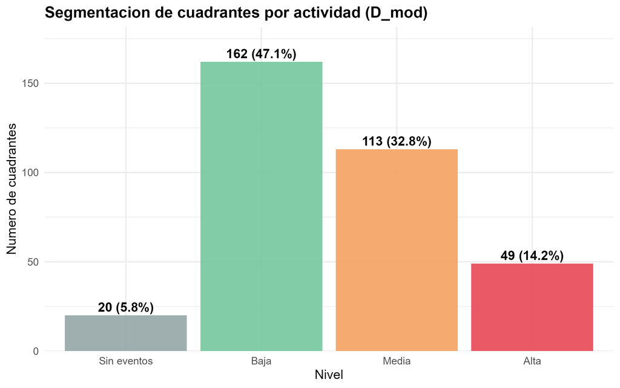

Las fallas se **concentran geográficamente**: un grupo reducido de zonas explica una parte desproporcionada de los eventos (el top 10 de zonas concentra el 20,5 %).

Identifica los **“puntos calientes” de la red** con nombre y ubicación. El hallazgo no evidente es que intervenir o modernizar ese pequeño conjunto de zonas críticas tendría un impacto mucho mayor en los indicadores que acciones distribuidas en toda la red.

# 6. Correlación y asociación (§5.3.7)

Método: **Spearman** (datos asimétricos y cero-inflados). Universo: $D_{\mathrm{mod}}$, 36 120 filas.

**Redundancia operativa:** $\rho$ hasta 0,99 (`usuarios_afectados`–`elementos_afectados`).

**Redundancia climática:** 10 pares con $|\rho| \geq 0{,}70$ (temperaturas y vientos); la precipitación no participa en ninguno.

**Clima → operativo:**

| Par | $\rho$ | $p$ |
| --- | --- | --- |
| `viento_max` ↔︎ `n_eventos` | 0,139 | < 0,001 |
| `viento_medio` ↔︎ `n_eventos` | 0,135 | < 0,001 |
| precip ↔︎ `duracion_total` | 0,069 | < 0,001 |
| precip ↔︎ `n_eventos` | 0,065 | < 0,001 |
| precip ↔︎ `usuarios_afectados` | 0,053 | < 0,001 |

**Condicionado** (`n_eventos > 0`; $n = 13\,351$): precip ↔︎ `n_eventos` se atenúa a $\rho = 0{,}029$ — la escasa señal está en la transición cero/no-cero, no en la intensidad del evento.

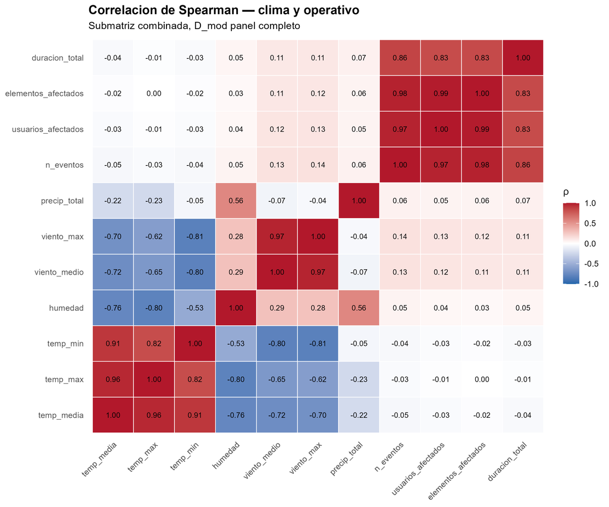

Mapa de calor clima–operativo (§5.3.7).

Un “mapa de calor” donde cada celda indica qué tan relacionadas están dos variables: colores intensos significan relación fuerte; colores tenues, relación débil.

Dos cosas. Primero, varias variables operativas miden prácticamente **lo mismo** (relación cercana a 1), igual que varias climáticas entre sí. Segundo, ninguna variable climática muestra una relación fuerte con las fallas: la más destacada es el **viento**, y aun así de magnitud modesta.

El hallazgo no evidente es que **se está midiendo información redundante**: no se necesitan decenas de variables para entender el fenómeno, sino unas pocas bien elegidas. Esto simplifica tableros, reportes y modelos, y reduce el costo de gestionar datos que no aportan información nueva.

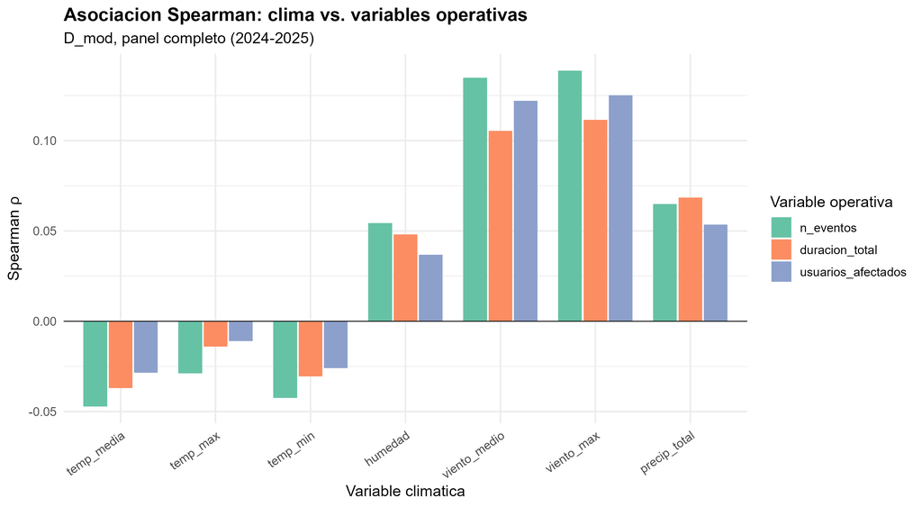

Barras: Spearman clima → operativo (§5.3.7).

El **viento encabeza el ranking**, la precipitación queda en segundo lugar con la mitad de la magnitud, y temperatura y humedad son prácticamente irrelevantes. Todas las barras son pequeñas en términos absolutos.

Prioriza dónde poner el foco y, sobre todo, **acota expectativas**: el clima contemporáneo medido a escala semanal no basta para anticipar fallas. El hallazgo no evidente es que la capacidad predictiva habrá que buscarla en el historial de la propia zona (rezagos y estacionalidad) más que en el pronóstico meteorológico.

# 7. Relaciones multivariadas (§5.3.8)

**VIF (bloque climático completo):** inflación crítica en temperaturas y vientos (hasta 43,92); `precip_total_semana` con VIF ≈ 1,50.

**Subconjunto propuesto para modelado:**

| Variable | VIF |
| --- | --- |
| `temp_media_semana` | 7,21 |
| `humedad_media_semana` | 4,47 |
| `viento_medio_semana` | 3,27 |
| `precip_total_semana` | 1,49 |

**PCA clima:** 87,3 % varianza en PC1–PC2; precipitación relativamente independiente (concentra su peso en PC2).

**Correlación parcial** precip ↔︎ `n_eventos` (controlando temp y viento): $\rho = 0{,}114$, frente a 0,065 bivariado.

**GLM Poisson exploratorio:** las cuatro covariables resultan significativas ($p < 0{,}001$), con temperatura media ($\hat{\beta} = 0{,}81$) y viento medio ($\hat{\beta} = 0{,}73$) por delante de humedad (0,35) y `log(1+precip)` (0,13). Dada la multicolinealidad, los coeficientes no admiten lectura causal individual.

**PCA operativo:** PC1 concentra 83,8 % — justifica **una** respuesta principal: `n_eventos` (proxy de frecuencia, asociada a SAIFI) o `duracion_total` (proxy de duración, asociada a SAIDI). Estas proxies **no** equivalen al cálculo regulatorio ponderado por usuarios.

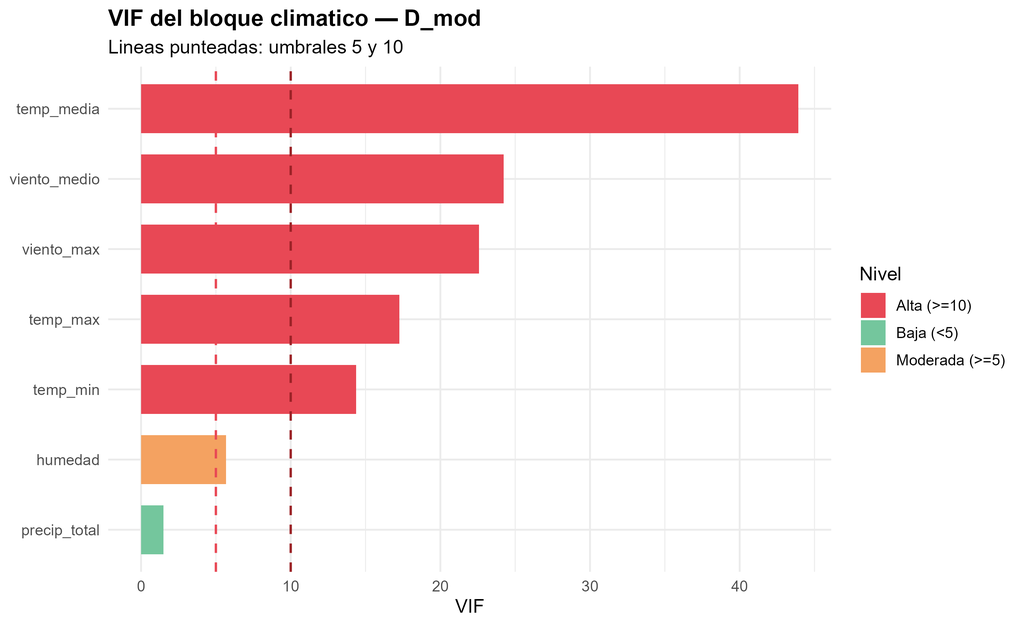

VIF del bloque climático (§5.3.8).

Mide cuánta información “repetida” aporta cada variable climática respecto a las demás: barras altas indican que la variable dice casi lo mismo que otra ya incluida.

Algunas variables (varias temperaturas y vientos) son **redundantes entre sí**, mientras que la **precipitación aporta información única**.

Justifica trabajar con un **conjunto reducido y limpio de variables**, sin perder capacidad de explicación. El hallazgo no evidente es que “más datos” no siempre es mejor: incluir variables redundantes puede confundir los modelos y encarecer su mantenimiento.

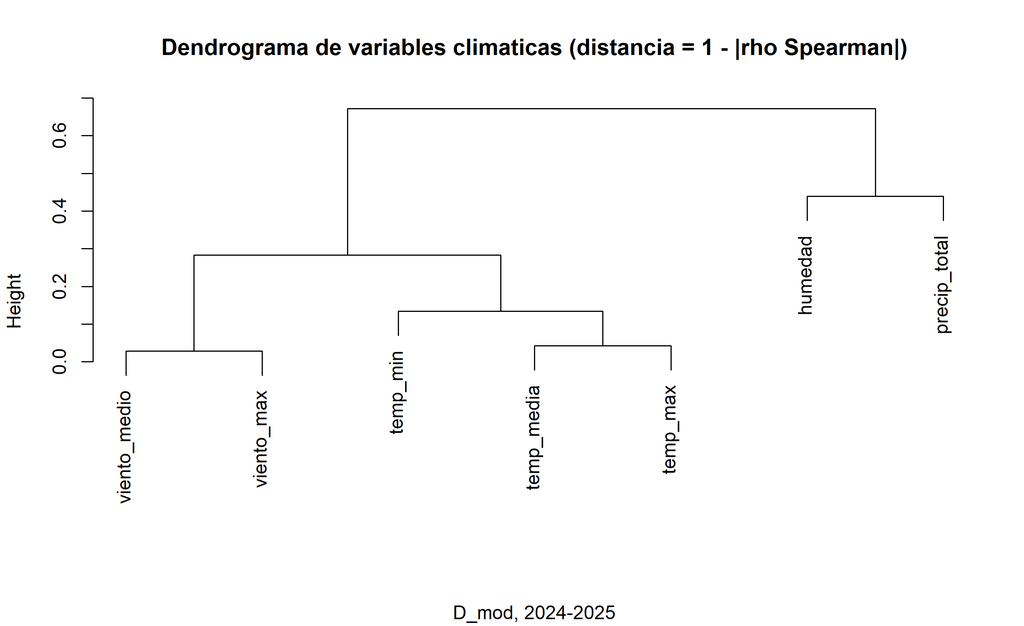

Dendrograma de variables climáticas (§5.3.8).

Un “árbol” que agrupa las variables climáticas por similitud: las que se unen antes son las más parecidas entre sí.

Las temperaturas forman un grupo, los vientos otro, y la **precipitación queda separada**, confirmando que mide algo distinto.

Respalda visualmente la decisión de **quedarse con un representante de cada grupo** más la precipitación. El hallazgo no evidente es que la complejidad climática puede resumirse en pocas dimensiones independientes, lo que facilita la comunicación y la toma de decisiones.

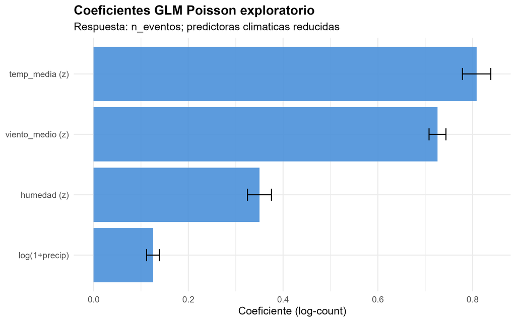

Coeficientes GLM Poisson exploratorio (§5.3.8).

Un primer modelo exploratorio que estima el efecto de cada factor climático sobre el número de fallas: barras hacia la derecha aumentan el riesgo, hacia la izquierda lo reducen.

Las cuatro variables salen significativas y con efecto positivo, encabezadas por **temperatura media y viento**; la lluvia queda en último lugar.

Es un primer diagnóstico cuantitativo del aporte conjunto del clima. El hallazgo no evidente es que el orden de importancia cambia respecto al análisis variable por variable: las temperaturas, irrelevantes por separado, ganan peso al combinarse, señal típica de variables que comparten información y advertencia de que estos coeficientes son exploratorios, no conclusiones causales.

# 8. Segmentación exploratoria (§5.3.9)

**Niveles de actividad** (cuadrantes con eventos; P50/P85):

| Nivel | Cuadrantes | % |
| --- | --- | --- |
| Baja | 162 | 47,1 |
| Media | 113 | 32,8 |
| Alta | 49 | 14,2 |
| Sin eventos | 20 | 5,8 |

**2024 vs 2025:** ratio medio eventos 2025/2024 ≈ 1,24–1,26 en todos los estratos.

**Régimen lluvioso (P75 = 24,7 mm):** media `n_eventos` 0,918 vs 0,927 en semanas secas — **sin diferencia significativa** (Wilcoxon $p = 0{,}175$).

**Clustering k-means ($k=4$):** hub extremo (C3, 1 cuadrante), cluster de mayor severidad (C1, 139 cuadrantes), cluster de altitud alta (C4, 126) y cluster más lluvioso pero de menor actividad (C2, 58).

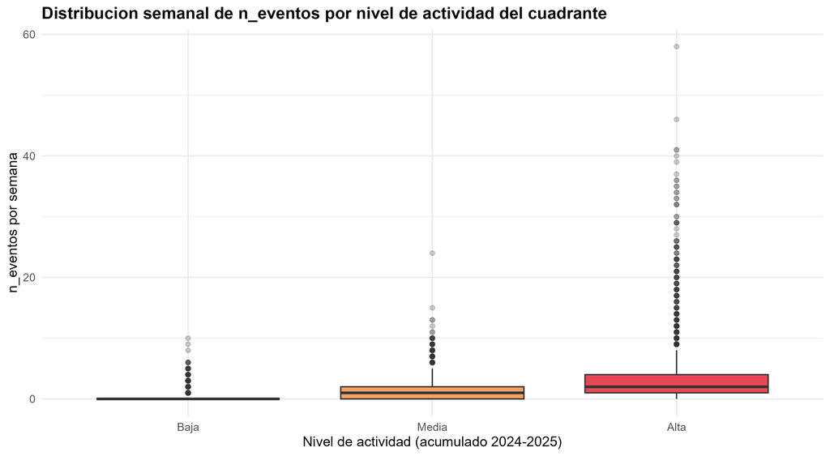

Frecuencia de eventos por nivel de actividad del cuadrante (Seccion 5.3.9).

Clasifica las zonas en niveles (baja, media, alta actividad) y compara cuántas fallas concentra cada grupo.

Un **14,2 % de las zonas** está en nivel “alta” y concentra una porción desproporcionada de los eventos, mientras casi la mitad tiene actividad baja. En contraste, clasificar las semanas por régimen de lluvia no separa nada: las semanas lluviosas registran 0,918 eventos en promedio frente a 0,927 en las secas.

Ofrece un criterio objetivo para **priorizar inversión y mantenimiento** en las zonas que más lo necesitan. El hallazgo no evidente es que un plan focalizado en ese 14 % de zonas críticas podría mejorar los indicadores globales de continuidad de forma más rentable que cualquier acción generalizada.

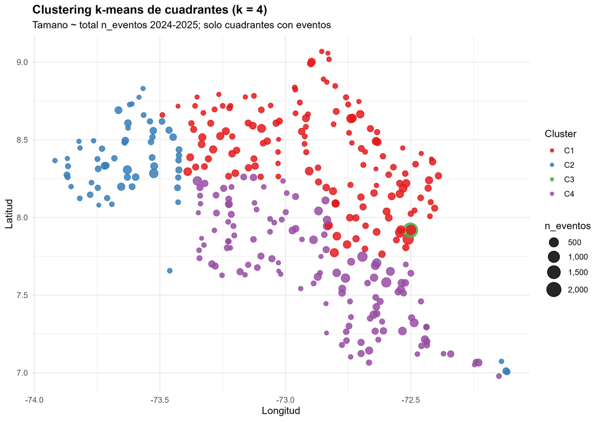

Clusters espaciales de cuadrantes (§5.3.9).

Agrupa las zonas en perfiles con comportamiento similar (frecuencia y severidad de fallas) y los ubica en el mapa.

Surgen perfiles bien diferenciados: desde un **“punto crítico” extremo** (una zona excepcional), pasando por un grupo de **alta severidad** (139 zonas de baja altitud), hasta un grupo de zonas altas (126) y otro de zonas lluviosas con menor actividad (58). No todas las zonas problemáticas lo son por la misma razón, y las más lluviosas no son las más críticas.

Permite diseñar **estrategias diferenciadas por tipo de zona** en lugar de una sola receta. El hallazgo no evidente es que existe un caso atípico que merece atención individual, y un bloque de zonas severas que justifican un programa específico de intervención.

# 9. Conclusiones y lineamientos para la Etapa 4 (§5.3.10)

## 9.0 Valor para la empresa

Más allá del detalle técnico, este análisis pone sobre la mesa cinco mensajes accionables para la organización:

1. **El dato operativo es confiable y la trazabilidad mejoró drásticamente desde 2024.** Esto habilita analítica avanzada sin grandes inversiones previas en limpieza, y obliga a leer con cuidado las comparaciones históricas de indicadores.
2. **Las fallas se concentran en pocas zonas y pocas semanas.** Focalizar recursos en los “puntos calientes” rinde mucho más que actuar sobre toda la red por igual.
3. **El clima semanal explica poco por sí solo.** Ninguna variable meteorológica muestra una relación fuerte con las fallas; el viento encabeza con margen estrecho y la lluvia acumulada de la semana resulta un predictor débil. Un tablero de riesgo basado únicamente en el pronóstico de lluvia no sería confiable.
4. **El comportamiento de las fallas es predecible, pero por su propia historia** (memoria semanal y estacionalidad clara), lo que permite planear cuadrillas, materiales y mantenimiento con anticipación sin depender del pronóstico meteorológico.
5. **La carga de eventos está creciendo**, lo que da urgencia a pasar de un enfoque reactivo a uno **preventivo y predictivo**.

En conjunto, los gráficos no solo describen el pasado: revelan **dónde, cuándo y bajo qué condiciones** es más probable que el servicio se vea afectado, información que puede traducirse en mejor anticipación operativa de la frecuencia y la duración de interrupciones (proxies asociadas a SAIDI/SAIFI) y en una asignación más eficiente del presupuesto.

## 9.1 Síntesis del EDA

El análisis exploratorio sobre el panel cuadrante × semana permitió:

1. **Validar calidad** del insumo agregado y acotar el horizonte de modelado a periodos con trazabilidad GIS homogénea.
2. **Caracterizar distribuciones** que exigen transformaciones y modelos para conteos y exceso de ceros.
3. **Identificar persistencia temporal** y estacionalidad que respaldan rezagos y partición cronológica.
4. **Cuantificar la señal climática** disponible en el grano semanal y establecer que es débil, lo que traslada el peso predictivo a la historia de la serie y al territorio.
5. **Depurar redundancias** multivariadas y proponer un conjunto mínimo de predictoras.
6. **Documentar heterogeneidad territorial** para eventual estratificación o efectos espaciales.

## 9.2 Decisiones propuestas para modelado

| Decisión | Propuesta |
| --- | --- |
| Universo de estimación | $D_{\mathrm{mod}}$ (2024–2025) |
| Partición | Entrenamiento 2024 / Prueba 2025 |
| Variable respuesta (frecuencia; proxy SAIFI) | `n_eventos` |
| Variable respuesta (duración; proxy SAIDI) | `duracion_total` (análisis complementario) |
| Alcance regulatorio | No se estima SAIDI/SAIFI CREG 015 (requiere $NU$/$UT$); se predicen proxies de frecuencia y duración |
| Predictoras climáticas | `precip_total_semana`, `temp_media_semana`, `humedad_media_semana`, `viento_medio_semana` |
| Excluir por redundancia | `temp_max/min`, `viento_max` |
| Transformaciones | `log(1+x)` en precipitación y bloque operativo según distribución |
| Rezagos / estacionalidad | Incorporar por ACF elevada (rezago 1 ≈ 0,80–0,92); principal fuente de señal predictiva |
| Clima a explorar | Indicadores de intensidad diaria y días de lluvia por semana, ante la debilidad del acumulado semanal |
| Estratificación opcional | Nivel *Alta* o clusters C1–C2 para modelos por zona |

## 9.3 Limitaciones reconocidas

- Los años 2021–2023 no son comparables en nivel absoluto por la brecha de codificación activo/sitio.
- El 63 % de filas en $D_{\mathrm{mod}}$ tiene `n_eventos = 0`; modelos deben contemplar inflación de ceros o enfoques de dos partes.
- Extremos de duración en días con evento requieren validación operativa antes de exclusiones.
- `n_eventos` y `duracion_total` son **proxies** de frecuencia y duración; **no** reproducen SAIDI/SAIFI regulatorios (ponderación por usuarios afectados y usuarios totales).

# 10. Conclusiones generales

El análisis descriptivo y exploratorio desarrollado en la Etapa 3 cumplió su propósito: **comprender el comportamiento de los datos de continuidad del servicio y extraer hallazgos accionables** que orientan tanto la gestión operativa como la construcción de modelos predictivos. Las conclusiones de mayor alcance son:

**Cierre.** En síntesis, los datos no solo describen lo ocurrido: revelan **dónde, cuándo y bajo qué condiciones** es más probable que se afecte el servicio. Esta comprensión constituye la base para la **Etapa 4 (modelado predictivo)**, en la que estos hallazgos se traducirán en herramientas concretas para anticipar la **frecuencia y la duración** de interrupciones (proxies asociadas a SAIFI/SAIDI), apoyar la gestión de continuidad y asignar el presupuesto operativo de manera más eficiente.

*Documento generado de forma reproducible desde `Scripts/Edwin/EDA.Rmd`. Versión: 2026-08-03.*